# Import libarires

```python
import mysql.connector
import os
import pandas as pd
import matplotlib.pyplot as plt
```

# Connecting to MySQL

```python
mydb = mysql.connector.connect(host='localhost',user='root',password='mypass',database='eco',use_pure=True)
cursor = mydb.cursor()
```

```python
# check the database table name
tables = 'show tables'
cursor.execute(tables)
tables = cursor.fetchall()

for i in tables:
    print(i)
```

```
('categories',)
('customers',)
('geolocation',)
('orderitems',)
('orderpayments',)
('orders',)
('products',)
('sellers',)
```

```python
# selecting the data tables from MySQL using SQL queries
query1 = 'select * from categories'
query2 = 'select * from customers'
query3 = 'select * from geolocation'
query4 = 'select * from orderitems'
query5 = 'select * from orderpayments'
query6 = 'select * from orders'
query7 = 'select * from products'
query8 = 'select * from sellers'
```

# Reading the data

```python
df_cat = pd.read_sql(query1, mydb)
df_cust = pd.read_sql(query2, mydb)
df_geo = pd.read_sql(query3, mydb)
df_oditems = pd.read_sql(query4, mydb)
df_odpay = pd.read_sql(query5, mydb)
df_od = pd.read_sql(query6, mydb)
df_pro = pd.read_sql(query7, mydb)
df_sell = pd.read_sql(query8, mydb)
```

```python
df_cat.head()
```

|  | ï»¿product_category_name | product_category_name_english |
| --- | --- | --- |
| 0 | beleza_saude | health_beauty\r |
| 1 | informatica_acessorios | computers_accessories\r |
| 2 | automotivo | auto\r |
| 3 | cama_mesa_banho | bed_bath_table\r |
| 4 | moveis_decoracao | furniture_decor\r |

```python
df_cust.head()
```

|  | "customer_id" | "customer_unique_id" | "customer_zip_code_prefix" | "customer_city" | "customer_state" |
| --- | --- | --- | --- | --- | --- |
| 0 | 06b8999e2fba1a1fbc88172c00ba8bc7 | 861eff4711a542e4b93843c6dd7febb0 | 14409 | franca | SP |
| 1 | 18955e83d337fd6b2def6b18a428ac77 | 290c77bc529b7ac935b93aa66c333dc3 | 09790 | sao bernardo do campo | SP |
| 2 | 4e7b3e00288586ebd08712fdd0374a03 | 060e732b5b29e8181a18229c7b0b2b5e | 01151 | sao paulo | SP |
| 3 | b2b6027bc5c5109e529d4dc6358b12c3 | 259dac757896d24d7702b9acbbff3f3c | 08775 | mogi das cruzes | SP |
| 4 | 4f2d8ab171c80ec8364f7c12e35b23ad | 345ecd01c38d18a9036ed96c73b8d066 | 13056 | campinas | SP |

```python
df_geo.head()
```

|  | "geolocation_zip_code_prefix" | "geolocation_lat" | "geolocation_lng" | "geolocation_city" | "geolocation_state" |
| --- | --- | --- | --- | --- | --- |
| 0 | 01037 | -23.54562128115268 | -46.63929204800168 | sao paulo | SP |
| 1 | 01046 | -23.546081127035535 | -46.64482029837157 | sao paulo | SP |
| 2 | 01046 | -23.54612896641469 | -46.64295148361138 | sao paulo | SP |
| 3 | 01041 | -23.5443921648681 | -46.63949930627844 | sao paulo | SP |
| 4 | 01035 | -23.541577961711493 | -46.64160722329613 | sao paulo | SP |

```python
df_oditems.head()
```

|  | "order_id" | "order_item_id" | "product_id" | "seller_id" | "shipping_limit_date" | "price" | "freight_value" |
| --- | --- | --- | --- | --- | --- | --- | --- |
| 0 | 00010242fe8c5a6d1ba2dd792cb16214 | 1 | 4244733e06e7ecb4970a6e2683c13e61 | 48436dade18ac8b2bce089ec2a041202 | 2017-09-19 09:45:35 | 58.90 | 13.29 |
| 1 | 00018f77f2f0320c557190d7a144bdd3 | 1 | e5f2d52b802189ee658865ca93d83a8f | dd7ddc04e1b6c2c614352b383efe2d36 | 2017-05-03 11:05:13 | 239.90 | 19.93 |
| 2 | 000229ec398224ef6ca0657da4fc703e | 1 | c777355d18b72b67abbeef9df44fd0fd | 5b51032eddd242adc84c38acab88f23d | 2018-01-18 14:48:30 | 199.00 | 17.87 |
| 3 | 00024acbcdf0a6daa1e931b038114c75 | 1 | 7634da152a4610f1595efa32f14722fc | 9d7a1d34a5052409006425275ba1c2b4 | 2018-08-15 10:10:18 | 12.99 | 12.79 |
| 4 | 00042b26cf59d7ce69dfabb4e55b4fd9 | 1 | ac6c3623068f30de03045865e4e10089 | df560393f3a51e74553ab94004ba5c87 | 2017-02-13 13:57:51 | 199.90 | 18.14 |

```python
df_odpay.head()
```

|  | "order_id" | "payment_sequential" | "payment_type" | "payment_installments" | "payment_value" |
| --- | --- | --- | --- | --- | --- |
| 0 | b81ef226f3fe1789b1e8b2acac839d17 | 1 | credit_card | 8 | 99.33 |
| 1 | a9810da82917af2d9aefd1278f1dcfa0 | 1 | credit_card | 1 | 24.39 |
| 2 | 25e8ea4e93396b6fa0d3dd708e76c1bd | 1 | credit_card | 1 | 65.71 |
| 3 | ba78997921bbcdc1373bb41e913ab953 | 1 | credit_card | 8 | 107.78 |
| 4 | 42fdf880ba16b47b59251dd489d4441a | 1 | credit_card | 2 | 128.45 |

```python
df_od.head()
```

|  | order_id | customer_id | order_status | order_purchase_timestamp | order_approved_at | order_delivered_carrier_date | order_delivered_customer_date | order_estimated_delivery_date |
| --- | --- | --- | --- | --- | --- | --- | --- | --- |
| 0 | e481f51cbdc54678b7cc49136f2d6af7 | 9ef432eb6251297304e76186b10a928d | delivered | 10/2/2017 10:56 | 10/2/2017 11:07 | 10/4/2017 19:55 | 10/10/2017 21:25 | 10/18/2017 0:00\r |
| 1 | 53cdb2fc8bc7dce0b6741e2150273451 | b0830fb4747a6c6d20dea0b8c802d7ef | delivered | 7/24/2018 20:41 | 7/26/2018 3:24 | 7/26/2018 14:31 | 8/7/2018 15:27 | 8/13/2018 0:00\r |
| 2 | 47770eb9100c2d0c44946d9cf07ec65d | 41ce2a54c0b03bf3443c3d931a367089 | delivered | 8/8/2018 8:38 | 8/8/2018 8:55 | 8/8/2018 13:50 | 8/17/2018 18:06 | 9/4/2018 0:00\r |
| 3 | 949d5b44dbf5de918fe9c16f97b45f8a | f88197465ea7920adcdbec7375364d82 | delivered | 11/18/2017 19:28 | 11/18/2017 19:45 | 11/22/2017 13:39 | 12/2/2017 0:28 | 12/15/2017 0:00\r |
| 4 | ad21c59c0840e6cb83a9ceb5573f8159 | 8ab97904e6daea8866dbdbc4fb7aad2c | delivered | 2/13/2018 21:18 | 2/13/2018 22:20 | 2/14/2018 19:46 | 2/16/2018 18:17 | 2/26/2018 0:00\r |

```python
df_pro.head()
```

|  | "product_id" | "product_category_name" | "product_name_lenght" | "product_description_lenght" | "product_photos_qty" | "product_weight_g" | "product_length_cm" | "product_height_cm" | "product_width_cm" |
| --- | --- | --- | --- | --- | --- | --- | --- | --- | --- |
| 0 | 1e9e8ef04dbcff4541ed26657ea517e5 | perfumaria | 40 | 287 | 1 | 225 | 16 | 10 | 14 |
| 1 | 3aa071139cb16b67ca9e5dea641aaa2f | artes | 44 | 276 | 1 | 1000 | 30 | 18 | 20 |
| 2 | 96bd76ec8810374ed1b65e291975717f | esporte_lazer | 46 | 250 | 1 | 154 | 18 | 9 | 15 |
| 3 | cef67bcfe19066a932b7673e239eb23d | bebes | 27 | 261 | 1 | 371 | 26 | 4 | 26 |
| 4 | 9dc1a7de274444849c219cff195d0b71 | utilidades_domesticas | 37 | 402 | 4 | 625 | 20 | 17 | 13 |

```python
df_sell.head()
```

|  | "seller_id" | "seller_zip_code_prefix" | "seller_city" | "seller_state" |
| --- | --- | --- | --- | --- |
| 0 | 3442f8959a84dea7ee197c632cb2df15 | 13023 | campinas | SP |
| 1 | d1b65fc7debc3361ea86b5f14c68d2e2 | 13844 | mogi guacu | SP |
| 2 | ce3ad9de960102d0677a81f5d0bb7b2d | 20031 | rio de janeiro | RJ |
| 3 | c0f3eea2e14555b6faeea3dd58c1b1c3 | 04195 | sao paulo | SP |
| 4 | 51a04a8a6bdcb23deccc82b0b80742cf | 12914 | braganca paulista | SP |

# Data Preparation

```python
df_cat.rename(columns={"ï»¿product_category_name" :"product_category_name"}, inplace=True)
```

```python
dataframes = [df_cat, df_cust, df_geo, df_oditems, df_odpay, df_od, df_pro, df_sell]

# Remove double quotes from table labels for each DataFrame
for df in dataframes:
    df.columns = df.columns.str.replace('"', '')
```

```python
df_cat.head()
```

|  | product_category_name | product_category_name_english |
| --- | --- | --- |
| 0 | beleza_saude | health_beauty\r |
| 1 | informatica_acessorios | computers_accessories\r |
| 2 | automotivo | auto\r |
| 3 | cama_mesa_banho | bed_bath_table\r |
| 4 | moveis_decoracao | furniture_decor\r |

```python
# checking the dataset shape
datasets = [df_cat, df_cust, df_geo, df_oditems, df_odpay, df_od, df_pro, df_sell]
data_name = ['df_cat', 'df_cust', 'df_geo', 'df_oditems', 'df_odpay', 'df_od', 'df_pro', 'df_sell']

for i in range(len(datasets)):
    row, col = datasets[i].shape
    print(data_name[i],'  \t',row, col)
```

```
df_cat   	 71 2
df_cust   	 99441 5
df_geo   	 1000163 5
df_oditems   	 112650 7
df_odpay   	 103886 5
df_od   	 99441 8
df_pro   	 32951 9
df_sell   	 3095 4
```

```python
# checking for null values
for i in range(len(datasets)):
    df = datasets[i]
    count_null = df.isnull().sum()
    print(data_name[i], count_null)
```

```
df_cat product_category_name            0
product_category_name_english    0
dtype: int64
df_cust customer_id                 0
customer_unique_id          0
customer_zip_code_prefix    0
customer_city               0
customer_state              0
dtype: int64
df_geo geolocation_zip_code_prefix    0
geolocation_lat                0
geolocation_lng                0
geolocation_city               0
geolocation_state              0
dtype: int64
df_oditems order_id               0
order_item_id          0
product_id             0
seller_id              0
shipping_limit_date    0
price                  0
freight_value          0
dtype: int64
df_odpay order_id                0
payment_sequential      0
payment_type            0
payment_installments    0
payment_value           0
dtype: int64
df_od order_id                         0
customer_id                      0
order_status                     0
order_purchase_timestamp         0
order_approved_at                0
order_delivered_carrier_date     0
order_delivered_customer_date    0
order_estimated_delivery_date    0
dtype: int64
df_pro product_id                    0
product_category_name         0
product_name_lenght           0
product_description_lenght    0
product_photos_qty            0
product_weight_g              0
product_length_cm             0
product_height_cm             0
product_width_cm              0
dtype: int64
df_sell seller_id                 0
seller_zip_code_prefix    0
seller_city               0
seller_state              0
dtype: int64
```

#### no null values if (any) it may be dropped while loading the data into MySQL server

```python
# check from duplicates
for i in range(len(datasets)):
    df = datasets[i]
    dup_count = df.duplicated().sum()
    print(data_name[i], dup_count)
```

```
df_cat 0
df_cust 0
df_geo 261831
df_oditems 0
df_odpay 0
df_od 0
df_pro 0
df_sell 0
```

```python
# drop the dulicated rows in df_geo dataset
df.geo = df_geo.drop_duplicates(inplace=True)
```

```python
# check again for duplicates
df_geo.duplicated().sum()
```

```
0
```

# Exploratory Data analysis

## 1- What are the top and least categories ordered?

```python
df_pro
```

|  | product_id | product_category_name | product_name_lenght | product_description_lenght | product_photos_qty | product_weight_g | product_length_cm | product_height_cm | product_width_cm |
| --- | --- | --- | --- | --- | --- | --- | --- | --- | --- |
| 0 | 1e9e8ef04dbcff4541ed26657ea517e5 | perfumaria | 40 | 287 | 1 | 225 | 16 | 10 | 14 |
| 1 | 3aa071139cb16b67ca9e5dea641aaa2f | artes | 44 | 276 | 1 | 1000 | 30 | 18 | 20 |
| 2 | 96bd76ec8810374ed1b65e291975717f | esporte_lazer | 46 | 250 | 1 | 154 | 18 | 9 | 15 |
| 3 | cef67bcfe19066a932b7673e239eb23d | bebes | 27 | 261 | 1 | 371 | 26 | 4 | 26 |
| 4 | 9dc1a7de274444849c219cff195d0b71 | utilidades_domesticas | 37 | 402 | 4 | 625 | 20 | 17 | 13 |
| ... | ... | ... | ... | ... | ... | ... | ... | ... | ... |
| 32946 | a0b7d5a992ccda646f2d34e418fff5a0 | moveis_decoracao | 45 | 67 | 2 | 12300 | 40 | 40 | 40 |
| 32947 | bf4538d88321d0fd4412a93c974510e6 | construcao_ferramentas_iluminacao | 41 | 971 | 1 | 1700 | 16 | 19 | 16 |
| 32948 | 9a7c6041fa9592d9d9ef6cfe62a71f8c | cama_mesa_banho | 50 | 799 | 1 | 1400 | 27 | 7 | 27 |
| 32949 | 83808703fc0706a22e264b9d75f04a2e | informatica_acessorios | 60 | 156 | 2 | 700 | 31 | 13 | 20 |
| 32950 | 106392145fca363410d287a815be6de4 | cama_mesa_banho | 58 | 309 | 1 | 2083 | 12 | 2 | 7 |

32951 rows × 9 columns

```python
# merge product and order items
order_info = pd.merge(df_pro[['product_id','product_category_name']],
                      df_oditems[['order_id','order_item_id', 'product_id']],
                     on='product_id',how='inner')
```

```python
orders_eng = pd.merge(order_info, df_cat, on='product_category_name', how='inner')
```

```python
orders_eng.head()
```

|  | product_id | product_category_name | order_id | order_item_id | product_category_name_english |
| --- | --- | --- | --- | --- | --- |
| 0 | 1e9e8ef04dbcff4541ed26657ea517e5 | perfumaria | e17e4f88e31525f7deef66779844ddce | 1 | perfumery\r |
| 1 | 6a2fb4dd53d2cdb88e0432f1284a004c | perfumaria | 048cc42e03ca8d43c729adf6962cb348 | 1 | perfumery\r |
| 2 | 6a2fb4dd53d2cdb88e0432f1284a004c | perfumaria | 5fa78e91b5cb84b6a8ccc42733f95742 | 1 | perfumery\r |
| 3 | 0d009643171aee696f4733340bc2fdd0 | perfumaria | 24b1c4d88fdb7a2dc87f8ecc7d8f47f1 | 1 | perfumery\r |
| 4 | 0d009643171aee696f4733340bc2fdd0 | perfumaria | 7b13c77c64a9a956500cbf1a9a23798d | 1 | perfumery\r |

```python
orders_eng.drop('product_category_name', axis=1, inplace=True)
orders_eng.head()
```

|  | product_id | order_id | order_item_id | product_category_name_english |
| --- | --- | --- | --- | --- |
| 0 | 1e9e8ef04dbcff4541ed26657ea517e5 | e17e4f88e31525f7deef66779844ddce | 1 | perfumery\r |
| 1 | 6a2fb4dd53d2cdb88e0432f1284a004c | 048cc42e03ca8d43c729adf6962cb348 | 1 | perfumery\r |
| 2 | 6a2fb4dd53d2cdb88e0432f1284a004c | 5fa78e91b5cb84b6a8ccc42733f95742 | 1 | perfumery\r |
| 3 | 0d009643171aee696f4733340bc2fdd0 | 24b1c4d88fdb7a2dc87f8ecc7d8f47f1 | 1 | perfumery\r |
| 4 | 0d009643171aee696f4733340bc2fdd0 | 7b13c77c64a9a956500cbf1a9a23798d | 1 | perfumery\r |

```
) missing from current font.
  fig.canvas.print_figure(bytes_io, **kw)
```

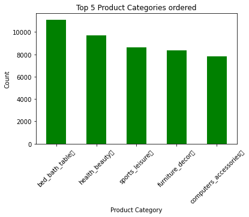

```python
# top 5 categories ordered

# Plotting the top 5 product categories
top_categories = orders_eng['product_category_name_english'].value_counts().head()
top_categories.plot(kind='bar', color='green', rot=45)

# Adding labels and title
plt.xlabel('Product Category')
plt.ylabel('Count')
plt.title('Top 5 Product Categories ordered')

# Display the plot
plt.show()
```

```
) missing from current font.
  fig.canvas.print_figure(bytes_io, **kw)
```

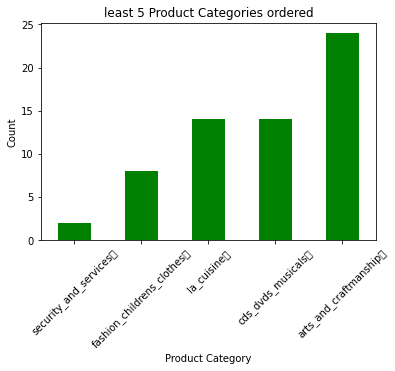

```python
# least 5 categories ordered

# Plotting the top 5 product categories
least_categories = orders_eng['product_category_name_english'].value_counts().tail()
least_categories = least_categories.sort_values(ascending=True)
least_categories.plot(kind='bar', color='green', rot=45)

# Adding labels and title
plt.xlabel('Product Category')
plt.ylabel('Count')
plt.title('least 5 Product Categories ordered')

# Display the plot
plt.show()
```

- Most ordered product category is bed bath table
- Least ordered product category is security and services

## 2- What is the order status?

```python
# order status percentage
((df_od.order_status.value_counts()/df_od.shape[0])*100)
```

```
delivered      97.020344
shipped         1.113223
canceled        0.628513
unavailable     0.612423
invoiced        0.315765
processing      0.302692
created         0.005028
approved        0.002011
Name: order_status, dtype: float64
```

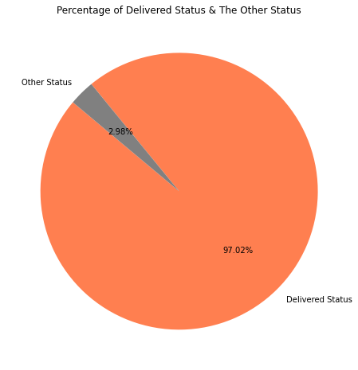

```python
first_order_status_percentage = (df_od['order_status'].value_counts() / df_od.shape[0] * 100)[0]

# Create a DataFrame with the first order status and its complement
data = pd.DataFrame({'Percentage': [first_order_status_percentage, 100 - first_order_status_percentage]},
                    index=['Delivered Status', 'Other Status'])

# Plotting a pie chart
plt.figure(figsize=(8, 8))
plt.pie(data['Percentage'], labels=data.index, autopct='%1.2f%%', startangle=140, colors=['coral', 'grey'])


plt.title('Percentage of Delivered Status & The Other Status')
plt.show()
```

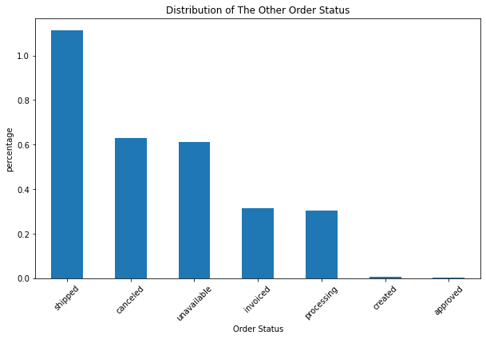

```python
order_status_counts = (df_od.query('order_status != "delivered"').order_status.value_counts()/df_od.shape[0])*100

# Plotting a bar chart
plt.figure(figsize=(10, 6))
order_status_counts.plot(kind='bar', rot=45)

plt.xlabel('Order Status')
plt.ylabel('percentage')
plt.title('Distribution of The Other Order Status')
plt.show()
```

```python
df_od.query('order_status == "canceled" or order_status == "unavailable"').order_status.value_counts()
```

```
canceled       625
unavailable    609
Name: order_status, dtype: int64
```

```python
round((df_od.query('order_status == "canceled"').order_status.value_counts()[0]/df_od.shape[0])*100,3)
```

```
0.629
```

```python
round((df_od.query('order_status == "unavailable"').order_status.value_counts()[0]/df_od.shape[0])*100,3)
```

```
0.612
```

- Most of the orders are delivered with 97.02%
- The percentage of an order to get canceled is 0.629%
- The percentage of an order to be unavailable is 0.612%

## 3- Which is the most used type of payment?

```python
(df_odpay.payment_type.value_counts()/df_odpay.shape[0])*100
```

```
credit_card    73.922376
boleto         19.043952
voucher         5.558978
debit_card      1.471806
not_defined     0.002888
Name: payment_type, dtype: float64
```

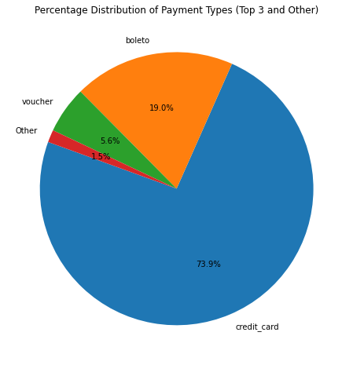

```python
payment_type_percentage = (df_odpay['payment_type'].value_counts() / df_odpay.shape[0]) * 100

# Get the top 3 payment types
top_3_payment_types = payment_type_percentage.head(3)

# Sum the percentages of other payment types
other_percentage = payment_type_percentage[3:].sum()

# Create a new DataFrame with the top 3 and the 'Other' category
plot_data = pd.concat([top_3_payment_types, pd.Series({'Other': other_percentage})])

plt.figure(figsize=(8, 8))
plt.pie(plot_data, labels=plot_data.index, autopct='%1.1f%%', startangle=160)
plt.title('Percentage Distribution of Payment Types (Top 3 and Other)')
plt.show()
```

- Most of the orders are paid using credit cards with a 73.9%

## 4- what are the top 10 cities that have most sellers and customers?

```python
df_sell.seller_city.value_counts().head(10)
```

```
sao paulo         694
curitiba          127
rio de janeiro     96
belo horizonte     68
ribeirao preto     52
guarulhos          50
ibitinga           49
santo andre        45
campinas           41
maringa            40
Name: seller_city, dtype: int64
```

```python
df_cust.customer_city.value_counts().head(10)
```

```
sao paulo                15540
rio de janeiro            6882
belo horizonte            2773
brasilia                  2131
curitiba                  1521
campinas                  1444
porto alegre              1379
salvador                  1245
guarulhos                 1189
sao bernardo do campo      938
Name: customer_city, dtype: int64
```

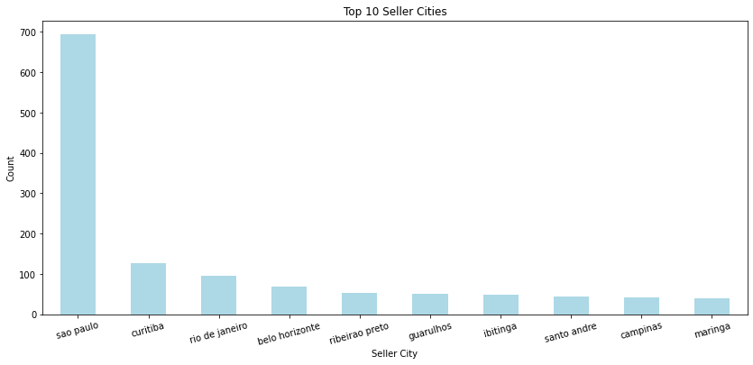

```python
top_seller_cities = df_sell['seller_city'].value_counts().head(10)

# Plotting a bar chart
plt.figure(figsize=(14, 6))
top_seller_cities.plot(kind='bar', color='lightblue',rot=15)

# Adding labels and title
plt.xlabel('Seller City')
plt.ylabel('Count')
plt.title('Top 10 Seller Cities')
plt.show()
```

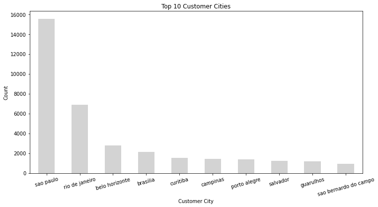

```python
top_customer_cities = df_cust['customer_city'].value_counts().head(10)

# Plotting a bar chart
plt.figure(figsize=(12, 6))
top_customer_cities.plot(kind='bar', color='lightgrey',rot=15)

plt.xlabel('Customer City')
plt.ylabel('Count')
plt.title('Top 10 Customer Cities')
plt.show()
```

- sao paulo has the most sellers and customers

## 5- Which city has the highest order cancellation?

```python
cust_od = pd.merge(df_cust[['customer_id','customer_city']],
                      df_od[['order_id','customer_id','order_status']],
                     on='customer_id',how='inner')
```

```python
cust_od.head()
```

|  | customer_id | customer_city | order_id | order_status |
| --- | --- | --- | --- | --- |
| 0 | 06b8999e2fba1a1fbc88172c00ba8bc7 | franca | 00e7ee1b050b8499577073aeb2a297a1 | delivered |
| 1 | 18955e83d337fd6b2def6b18a428ac77 | sao bernardo do campo | 29150127e6685892b6eab3eec79f59c7 | delivered |
| 2 | 4e7b3e00288586ebd08712fdd0374a03 | sao paulo | b2059ed67ce144a36e2aa97d2c9e9ad2 | delivered |
| 3 | b2b6027bc5c5109e529d4dc6358b12c3 | mogi das cruzes | 951670f92359f4fe4a63112aa7306eba | delivered |
| 4 | 4f2d8ab171c80ec8364f7c12e35b23ad | campinas | 6b7d50bd145f6fc7f33cebabd7e49d0f | delivered |

```python
# Filter data for canceled orders
canceled_orders = cust_od[cust_od['order_status'] == 'canceled']

# Get the canceled order distribution by customer city
canceled_orders_by_city = canceled_orders['customer_city'].value_counts().head(20)
canceled_orders_by_city
```

```
sao paulo                140
rio de janeiro            48
belo horizonte            17
guarulhos                 13
campinas                  11
curitiba                  10
sao bernardo do campo      8
osasco                     8
brasilia                   7
goiania                    7
sorocaba                   7
jundiai                    6
santo andre                6
florianopolis              5
porto alegre               5
fortaleza                  4
salvador                   4
vila velha                 4
contagem                   4
governador valadares       4
Name: customer_city, dtype: int64
```

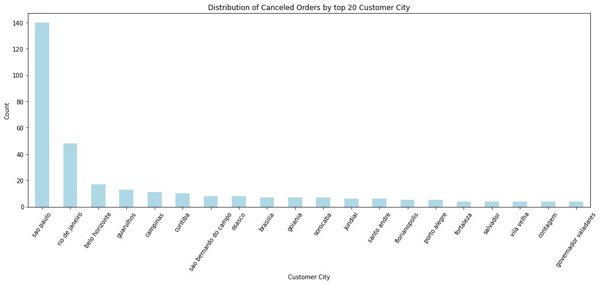

```python
canceled_orders_by_city.plot(kind='bar', color='lightblue', figsize=(17, 6),rot=55)
plt.xlabel('Customer City')
plt.ylabel('Count')
plt.title('Distribution of Canceled Orders by top 20 Customer City')
```

- sao paulo has the most order cancellation with 140 cancels
- rio de janeiro comes in the second place with 48 cancels

# Conculsion

- Most ordered product category is bed bath table
- Least ordered product category is security and services
- Most of the orders are delivered with 97.02%
- The percentage of an order to get canceled is 0.629%
- The percentage of an order to be unavailable is 0.612%
- Most of the orders are paid using credit cards with a 73.9%
- Sao Paulo has the most sellers and customers
- Sao Paulo has the most order cancellation with 140 cancels
- Rio de Janeiro comes in the second place with 48 cancels